# glinski_metabolites

```
## (Intercept)   Time[ind]
##  0.76080280  0.02102169
##             2.5 % 97.5 %
## (Intercept)    NA     NA
## Time[ind]      NA     NA
## [1] "##################################################"
## [1] "##################################################"
## [1] "Substrate =  250"
##  [1] "Indices =  104" "Indices =  105" "Indices =  106" "Indices =  107"
##  [5] "Indices =  108" "Indices =  109" "Indices =  110" "Indices =  111"
##  [9] "Indices =  112" "Indices =  113" "Indices =  114" "Indices =  115"
## [13] "Indices =  116" "Indices =  117" "Indices =  118"
##  [1] "Times = 0"  "Times = 0"  "Times = 0"  "Times = 15" "Times = 15"
##  [6] "Times = 15" "Times = 30" "Times = 30" "Times = 30" "Times = 60"
## [11] "Times = 60" "Times = 60" "Times = 90" "Times = 90" "Times = 90"
##  [1] "Concs = 0"           "Concs = 0"           "Concs = 0"
##  [4] "Concs = 0.688691412" "Concs = 0.680203691" "Concs = 0.671715969"
##  [7] "Concs = 1.128032043" "Concs = 1.057705208" "Concs = 1.0791266"
## [10] "Concs = 1.670842039" "Concs = 1.655483305" "Concs = 1.672054571"
## [13] "Concs = 2.11584115"  "Concs = 2.394723427" "Concs = 2.276703681"
## Call:
## rlm(formula = Observed[ind] ~ Time[ind])
## Converged in 1 iterations
##
## Coefficients:
## (Intercept)   Time[ind]
##  0.21108314  0.02380321
##
## Degrees of freedom: 15 total; 13 residual
## Scale estimate: 0.179
##
## Call: rlm(formula = Observed[ind] ~ Time[ind])
## Residuals:
##      Min       1Q   Median       3Q      Max
## -0.23753 -0.14388  0.03278  0.11632  0.20285
##
## Coefficients:
##             Value   Std. Error t value
## (Intercept)  0.2111  0.0635     3.3230
## Time[ind]    0.0238  0.0013    18.9784
##
## Residual standard error: 0.1787 on 13 degrees of freedom
```

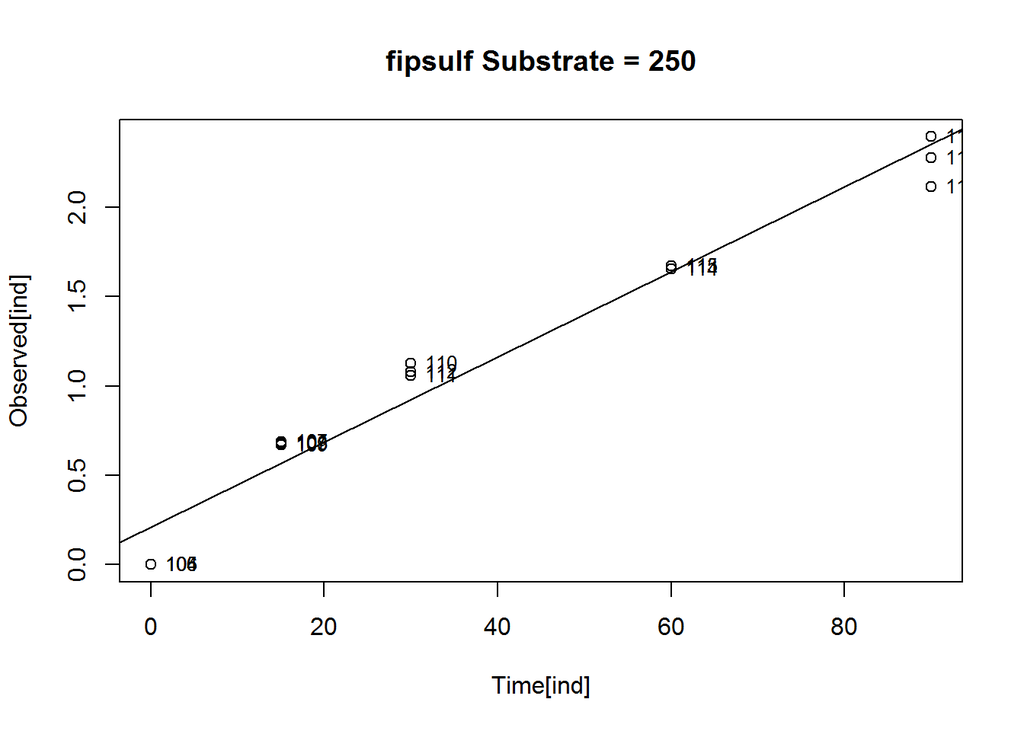

```
## (Intercept)   Time[ind]
##  0.21108314  0.02380321
##             2.5 % 97.5 %
## (Intercept)    NA     NA
## Time[ind]      NA     NA
## [1] "##################################################"
```

```
## 'data.frame':    8 obs. of  2 variables:
##  $ sub: num  10 2.89 50 75 100 125 150 250
##  $ vel: num  103 47.3 107.9 56.4 92.6 ...
##      sub       vel
## 1  10.00 103.01524
## 2   2.89  47.31387
## 3  50.00 107.91797
## 4  75.00  56.39019
## 5 100.00  92.56888
## 6 125.00 105.73549
## 7 150.00 105.10846
## 8 250.00 119.01603
```

```
## [1] "here are the rates"
```

```
##
## Model fitted: Michaelis-Menten (2 parms)
##
## Parameter estimates:
##
##               Estimate Std. Error t-value   p-value
## d:(Intercept) 102.0337     9.5991  10.630 4.085e-05 ***
## e:(Intercept)   2.2813     1.7809   1.281    0.2475
## ---
## Signif. codes:  0 '***' 0.001 '**' 0.01 '*' 0.05 '.' 0.1 ' ' 1
##
## Residual standard error:
##
##  21.75614 (6 degrees of freedom)
```

```
## No test available
##
##           ModelDf Log lik Df Chisq value p value
##
## DRC model
```

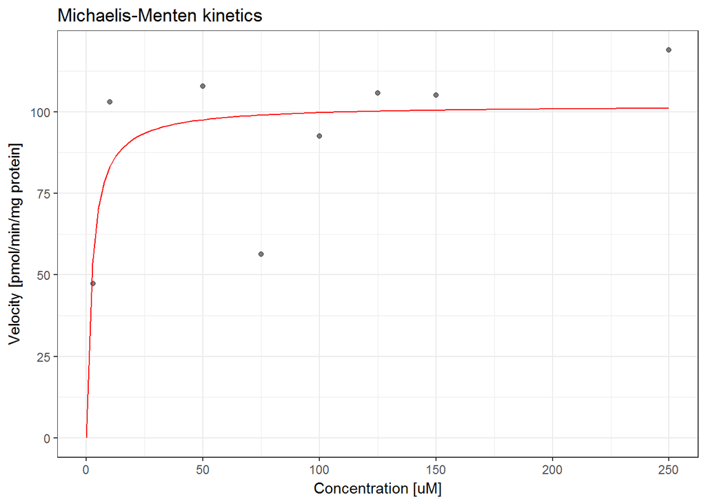

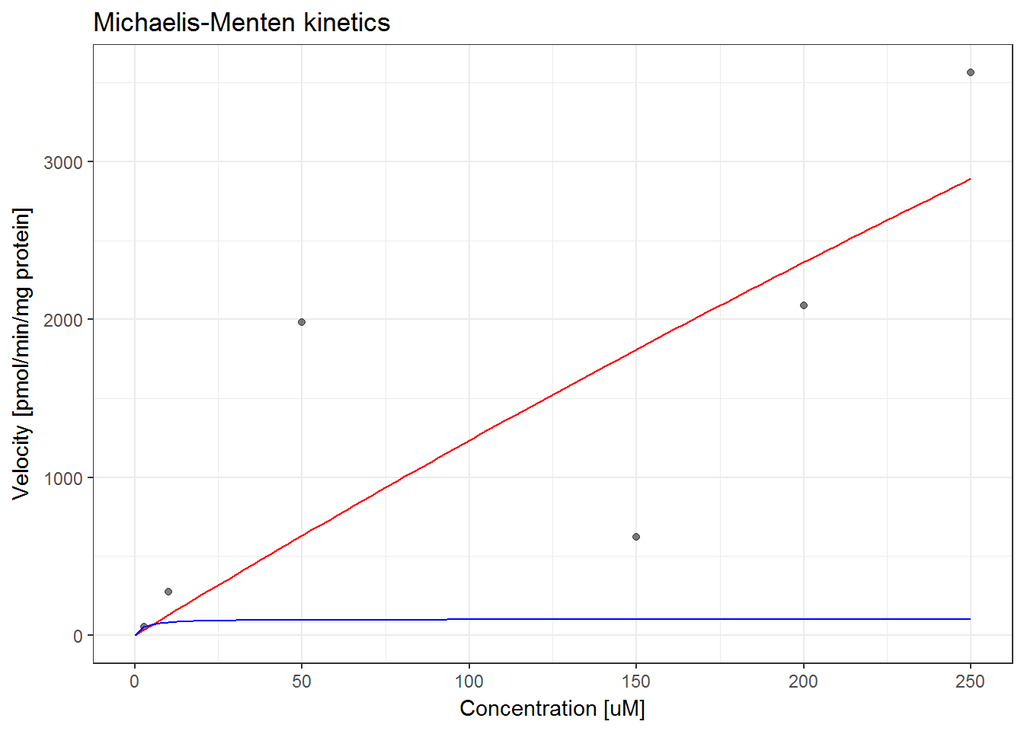

# exposure experiment analysis

Results presentation and discussion for parent analytes (atrazine, triadimenon, and fipronil) and their xenobiotic metabolites.

Toxicity of parents and metabolites discussion.

Microsomal analysis of soil and amphibian data for 0 (soil only), 2, 4, 12, 24, and 48 hours after exposure.

Database has factors for time, parent (mapped to analyte), analyte (can be either parent or metabolite), matrix (amphibian or soil), and tank (potentially a nuisance variable).

[output not shown]

[output cut: 50 more lines]

[output not shown]

```
## # A tibble: 352 x 6
## # Groups: parent, analyte, matrix, time [86]
##     time parent   analyte matrix  conc replicate
##    <int> <fctr>   <fctr>  <fctr> <dbl> <fctr>
##  1     2 atrazine ATZ     amphib  3.07 1
##  2     2 atrazine ATZ     amphib  3.69 2
##  3     2 atrazine ATZ     amphib  4.70 3
##  4     2 atrazine ATZ     amphib  1.89 4
##  5     4 atrazine ATZ     amphib  7.62 1
##  6     4 atrazine ATZ     amphib  4.13 2
##  7     4 atrazine ATZ     amphib  2.05 3
##  8     4 atrazine ATZ     amphib  7.63 4
##  9    12 atrazine ATZ     amphib  2.45 1
## 10    12 atrazine ATZ     amphib  3.79 2
## # ... with 342 more rows
```

```
## # A tibble: 86 x 7
## # Groups: parent, analyte, matrix [?]
##    parent   analyte matrix  time count ConcMean ConcSD
##    <fctr>   <fctr>  <fctr> <int> <int>    <dbl>  <dbl>
##  1 atrazine ATZ     amphib     2     4     3.34  1.18
##  2 atrazine ATZ     amphib     4     4     5.36  2.75
##  3 atrazine ATZ     amphib    12     4     3.12  1.26
##  4 atrazine ATZ     amphib    24     4     1.55  0.610
##  5 atrazine ATZ     amphib    48     4     1.00  0.355
##  6 atrazine ATZ     soil       0     4    15.9   2.59
##  7 atrazine ATZ     soil       2     4    19.0   4.35
##  8 atrazine ATZ     soil       4     4    18.8   2.70
##  9 atrazine ATZ     soil      12     4    20.6   3.89
## 10 atrazine ATZ     soil      24     4    25.0   4.45
## # ... with 76 more rows
```

[output not shown]

[output cut: 65 more lines]

The amphibian data set summary statistics. Atrazine peaks at 4 hours and then declines monotonically. DEA peaks at 12 hours and DIA at 24. Fipronil steadily declines from its first observation at 2 hours with fipronil sulfone not peaking until 24 hours. Triadimenon peaks at 24 hours with its metabolites tdla and tdlb peaking at 4 hours.

```
## Classes 'grouped_df', 'tbl_df', 'tbl' and 'data.frame':  86 obs. of  7 variables:
##  $ parent  : Factor w/ 3 levels "atrazine","fipronil",..: 1 1 1 1 1 1 1 1 1 1 ...
##  $ analyte : Factor w/ 8 levels "ATZ","DEA","DIA",..: 1 1 1 1 1 1 1 1 1 1 ...
##  $ matrix  : Factor w/ 2 levels "amphib","soil": 1 1 1 1 1 2 2 2 2 2 ...
##  $ time    : int  2 4 12 24 48 0 2 4 12 24 ...
##  $ count   : int  4 4 4 4 4 4 4 4 4 4 ...
##  $ ConcMean: num  3.34 5.36 3.12 1.55 1 ...
##  $ ConcSD  : num  1.175 2.752 1.257 0.61 0.355 ...
##  - attr(*, "vars")= chr  "parent" "analyte" "matrix"
##  - attr(*, "drop")= logi TRUE
```

```
## # A tibble: 6 x 7
## # Groups: parent, analyte, matrix [2]
##   parent   analyte matrix  time count ConcMean  ConcSD
##   <fctr>   <fctr>  <fctr> <int> <int>    <dbl>   <dbl>
## 1 atrazine ATZ     amphib     2     4   3.34   1.18
## 2 atrazine ATZ     amphib     4     4   5.36   2.75
## 3 atrazine ATZ     amphib    12     4   3.12   1.26
## 4 atrazine ATZ     amphib    24     4   1.55   0.610
## 5 atrazine ATZ     amphib    48     4   1.00   0.355
## 6 atrazine DEA     amphib     2     4   0.0139 0.00522
```

```
## # A tibble: 15 x 7
## # Groups: parent, analyte, matrix [3]
##    parent   analyte matrix  time count ConcMean  ConcSD
##    <fctr>   <fctr>  <fctr> <int> <int>    <dbl>   <dbl>
##  1 atrazine ATZ     amphib     2     4   3.34   1.18
##  2 atrazine ATZ     amphib     4     4   5.36   2.75
##  3 atrazine ATZ     amphib    12     4   3.12   1.26
##  4 atrazine ATZ     amphib    24     4   1.55   0.610
##  5 atrazine ATZ     amphib    48     4   1.00   0.355
##  6 atrazine DEA     amphib     2     4   0.0139 0.00522
##  7 atrazine DEA     amphib     4     4   0.0444 0.0284
##  8 atrazine DEA     amphib    12     4   0.0540 0.0128
##  9 atrazine DEA     amphib    24     4   0.0365 0.0131
## 10 atrazine DEA     amphib    48     4   0.0195 0.0196
## 11 atrazine DIA     amphib     2     4   0.329  0.125
## 12 atrazine DIA     amphib     4     4   0.942  0.761
## 13 atrazine DIA     amphib    12     4   1.08   0.506
## 14 atrazine DIA     amphib    24     4   1.99   1.35
## 15 atrazine DIA     amphib    48     4   0.662  0.531
```

```
## [1] "ATZ"
## [1] "DEA"
## [1] "DIA"
```

```
## # A tibble: 10 x 7
## # Groups: parent, analyte, matrix [2]
##    parent   analyte    matrix  time count ConcMean ConcSD
##    <fctr>   <fctr>     <fctr> <int> <int>    <dbl>  <dbl>
##  1 fipronil F. sulfone amphib     2     4    0.347 0.287
##  2 fipronil F. sulfone amphib     4     4    0.397 0.477
##  3 fipronil F. sulfone amphib    12     4    0.613 0.573
##  4 fipronil F. sulfone amphib    24     4    1.25  0.526
##  5 fipronil F. sulfone amphib    48     4    0.907 0.566
##  6 fipronil FIP        amphib     2     4    1.87  1.35
##  7 fipronil FIP        amphib     4     4    1.30  0.522
##  8 fipronil FIP        amphib    12     4    0.566 0.240
##  9 fipronil FIP        amphib    24     4    0.268 0.0511
## 10 fipronil FIP        amphib    48     4    0.212 0.131
```

```
## # A tibble: 0 x 7
## # Groups: parent, analyte, matrix [0]
## # ... with 7 variables: parent <fctr>, analyte <fctr>, matrix <fctr>, time
## #   <int>, count <int>, ConcMean <dbl>, ConcSD <dbl>
```

The soil data set summary statistics. Atrazine in soil showing an upwards trend (need to test if significant) with dia and dea levels very low indicating little degradation in soil over the 48 hour period. Fipronil and triadimenon data also indicating little degradation in soil.

```
## # A tibble: 18 x 7
## # Groups: parent, analyte, matrix [3]
##    parent   analyte matrix  time count  ConcMean   ConcSD
##    <fctr>   <fctr>  <fctr> <int> <int>     <dbl>    <dbl>
##  1 atrazine ATZ     soil       0     4  15.9     2.59
##  2 atrazine ATZ     soil       2     4  19.0     4.35
##  3 atrazine ATZ     soil       4     4  18.8     2.70
##  4 atrazine ATZ     soil      12     4  20.6     3.89
##  5 atrazine ATZ     soil      24     4  25.0     4.45
##  6 atrazine ATZ     soil      48     4  26.4     4.38
##  7 atrazine DEA     soil       0     4   0       0
##  8 atrazine DEA     soil       2     4   0.00157 0.000633
##  9 atrazine DEA     soil       4     4   0.00300 0.00154
## 10 atrazine DEA     soil      12     4   0.00547 0.00423
## 11 atrazine DEA     soil      24     4   0.00731 0.00174
## 12 atrazine DEA     soil      48     4   0.00878 0.00377
## 13 atrazine DIA     soil       0     4   0       0
## 14 atrazine DIA     soil       2     4 - 0.00773 0.00737
## 15 atrazine DIA     soil       4     4   0.0205  0.0202
## 16 atrazine DIA     soil      12     4   0.0770  0.0678
## 17 atrazine DIA     soil      24     4   0.0430  0.0300
## 18 atrazine DIA     soil      48     4   0.0637  0.0582
```

```
## # A tibble: 10 x 7
## # Groups: parent, analyte, matrix [2]
##    parent   analyte    matrix  time count ConcMean  ConcSD
##    <fctr>   <fctr>     <fctr> <int> <int>    <dbl>   <dbl>
##  1 fipronil F. sulfone soil       2     8   0.0102 0.0129
##  2 fipronil F. sulfone soil       4     4   0.0219 0.0108
##  3 fipronil F. sulfone soil      12     4   0.0183 0.00501
##  4 fipronil F. sulfone soil      24     4   0.0192 0.00914
##  5 fipronil F. sulfone soil      48     4   0.0126 0.00552
##  6 fipronil FIP        soil       2     8   0.408  0.447
##  7 fipronil FIP        soil       4     4   0.868  0.244
##  8 fipronil FIP        soil      12     4   0.817  0.170
##  9 fipronil FIP        soil      24     4   0.702  0.109
## 10 fipronil FIP        soil      48     4   0.356  0.0585
```

```
## # A tibble: 0 x 7
## # Groups: parent, analyte, matrix [0]
## # ... with 7 variables: parent <fctr>, analyte <fctr>, matrix <fctr>, time
## #   <int>, count <int>, ConcMean <dbl>, ConcSD <dbl>
```

```r
pdf(paste(micro.graphics,"data_mean_barcharts",".pdf", sep=""))
  par(mfrow=c(3,1))
  print(parents)
```

```
## [1] atrazine    triadimefon fipronil
## Levels: atrazine fipronil triadimefon
```

```r
  for(parent in parents){
    i=0
    print(parent)
    temp.parent <- micro.group.stats.amphib[which(micro.group.stats.amphib$parent==parent),]
    print(temp.parent)
    parent.analytes <- unique(temp.parent$analyte)
    for(analyte in parent.analytes){
      print(parent)
      print(analyte)
      analytetemp <- micro.group.stats.amphib[which(micro.group.stats.amphib$analyte==analyte),]
      xvalues <- as.numeric(as.character(analytetemp$time))
      points.y <- micro.amphib[which(micro.amphib$analyte==analyte),]$conc
      points.x <- as.numeric(as.character(micro.amphib[which(micro.amphib$analyte==analyte),]$time))
      #create empty plot if needed
      if(i==0){
        parenttemp <- micro.group.stats.amphib[which(micro.group.stats.amphib$parent==parent),]
        maxconc <- max(points.y)
        #plot(xvalues,analytetemp$ConcMean,type="l", xlim=c(0,48),
        #     ylim = c(0,maxconc), main=parent,col="black", xlab="Hours", ylab="Concentration")
        #axis(1,at=xvalues)
        i=1
      }
      ##add line for parent metabolite
      #if(analyte %in% parents){
      #  lines(xvalues,analytetemp$ConcMean,type="l",col="red")
      #  points(points.x, points.y, col = "red")
      #}else{
      ##add line for daughter metabolite
      #  lines(xvalues,analytetemp$ConcMean,type="l",col="blue")
      #  points(points.x, points.y, col = "blue")
      #}
    }
  }
```

```
## [1] "atrazine"
## # A tibble: 15 x 7
## # Groups: parent, analyte, matrix [3]
##    parent   analyte matrix  time count ConcMean  ConcSD
##    <fctr>   <fctr>  <fctr> <int> <int>    <dbl>   <dbl>
##  1 atrazine ATZ     amphib     2     4   3.34   1.18
##  2 atrazine ATZ     amphib     4     4   5.36   2.75
##  3 atrazine ATZ     amphib    12     4   3.12   1.26
##  4 atrazine ATZ     amphib    24     4   1.55   0.610
##  5 atrazine ATZ     amphib    48     4   1.00   0.355
##  6 atrazine DEA     amphib     2     4   0.0139 0.00522
##  7 atrazine DEA     amphib     4     4   0.0444 0.0284
##  8 atrazine DEA     amphib    12     4   0.0540 0.0128
##  9 atrazine DEA     amphib    24     4   0.0365 0.0131
## 10 atrazine DEA     amphib    48     4   0.0195 0.0196
```

[output cut: 56 more lines]

```r
dev.off()
```

```r
pdf(paste(micro.graphics,"data_mean_scatterplot",".pdf", sep=""))
  par(mfrow=c(3,1))
  print(parents)
```

```
## [1] atrazine    triadimefon fipronil
## Levels: atrazine fipronil triadimefon
```

```r
  for(parent in parents){
    i=0
    print(parent)
    temp.parent <- micro.group.stats.amphib[which(micro.group.stats.amphib$parent==parent),]
    print(temp.parent)
    parent.analytes <- unique(temp.parent$analyte)
    for(analyte in parent.analytes){
      print(parent)
      print(analyte)
      analytetemp <- micro.group.stats.amphib[which(micro.group.stats.amphib$analyte==analyte),]
      xvalues <- as.numeric(as.character(analytetemp$time))
      points.y <- micro.amphib[which(micro.amphib$analyte==analyte),]$conc
      points.x <- as.numeric(as.character(micro.amphib[which(micro.amphib$analyte==analyte),]$time))
      #create empty plot if needed
      if(i==0){
        parenttemp <- micro.group.stats.amphib[which(micro.group.stats.amphib$parent==parent),]
        maxconc <- max(points.y)
        plot(xvalues,analytetemp$ConcMean,type="l", xlim=c(0,48),
             ylim = c(0,maxconc), main=parent,col="black", xlab="Hours", ylab="Concentration")
        axis(1,at=xvalues)
        i=1
      }
      #add line for parent metabolite
      if(analyte %in% parents){
        lines(xvalues,analytetemp$ConcMean,type="l",col="red")
        points(points.x, points.y, col = "red")
      }else{
      #add line for daughter metabolite
        lines(xvalues,analytetemp$ConcMean,type="l",col="blue")
        points(points.x, points.y, col = "blue")
      }
    }
  }
```

```
## [1] "atrazine"
## # A tibble: 15 x 7
## # Groups: parent, analyte, matrix [3]
##    parent   analyte matrix  time count ConcMean  ConcSD
##    <fctr>   <fctr>  <fctr> <int> <int>    <dbl>   <dbl>
##  1 atrazine ATZ     amphib     2     4   3.34   1.18
##  2 atrazine ATZ     amphib     4     4   5.36   2.75
##  3 atrazine ATZ     amphib    12     4   3.12   1.26
##  4 atrazine ATZ     amphib    24     4   1.55   0.610
##  5 atrazine ATZ     amphib    48     4   1.00   0.355
##  6 atrazine DEA     amphib     2     4   0.0139 0.00522
##  7 atrazine DEA     amphib     4     4   0.0444 0.0284
##  8 atrazine DEA     amphib    12     4   0.0540 0.0128
##  9 atrazine DEA     amphib    24     4   0.0365 0.0131
## 10 atrazine DEA     amphib    48     4   0.0195 0.0196
## 11 atrazine DIA     amphib     2     4   0.329  0.125
## 12 atrazine DIA     amphib     4     4   0.942  0.761
## 13 atrazine DIA     amphib    12     4   1.08   0.506
## 14 atrazine DIA     amphib    24     4   1.99   1.35
## 15 atrazine DIA     amphib    48     4   0.662  0.531
## [1] "atrazine"
## [1] "ATZ"
```

```
## [1] "atrazine"
## [1] "DEA"
## [1] "atrazine"
## [1] "DIA"
## [1] "triadimefon"
## # A tibble: 15 x 7
## # Groups: parent, analyte, matrix [3]
##    parent      analyte matrix  time count ConcMean  ConcSD
##    <fctr>      <fctr>  <fctr> <int> <int>    <dbl>   <dbl>
##  1 triadimefon TDL A   amphib     2     4   0.0551 0.0211
##  2 triadimefon TDL A   amphib     4     4   0.0815 0.0462
##  3 triadimefon TDL A   amphib    12     4   0.0363 0.0152
##  4 triadimefon TDL A   amphib    24     4   0.0240 0.00752
##  5 triadimefon TDL A   amphib    48     4   0.0155 0.00485
##  6 triadimefon TDL B   amphib     2     4   0.0836 0.0164
##  7 triadimefon TDL B   amphib     4     4   0.130  0.0543
##  8 triadimefon TDL B   amphib    12     4   0.0766 0.0486
##  9 triadimefon TDL B   amphib    24     4   0.0418 0.0117
## 10 triadimefon TDL B   amphib    48     4   0.0295 0.00344
## 11 triadimefon TDN     amphib     2     4   0.387  0.0759
## 12 triadimefon TDN     amphib     4     4   0.549  0.300
## 13 triadimefon TDN     amphib    12     4   0.755  0.318
## 14 triadimefon TDN     amphib    24     4   0.865  0.860
## 15 triadimefon TDN     amphib    48     4   0.249  0.0798
## [1] "triadimefon"
## [1] "TDL A"
```

```
## [1] "triadimefon"
## [1] "TDL B"
## [1] "triadimefon"
## [1] "TDN"
## [1] "fipronil"
## # A tibble: 10 x 7
## # Groups: parent, analyte, matrix [2]
##    parent   analyte    matrix  time count ConcMean ConcSD
##    <fctr>   <fctr>     <fctr> <int> <int>    <dbl>  <dbl>
##  1 fipronil F. sulfone amphib     2     4    0.347 0.287
##  2 fipronil F. sulfone amphib     4     4    0.397 0.477
##  3 fipronil F. sulfone amphib    12     4    0.613 0.573
##  4 fipronil F. sulfone amphib    24     4    1.25  0.526
##  5 fipronil F. sulfone amphib    48     4    0.907 0.566
##  6 fipronil FIP        amphib     2     4    1.87  1.35
##  7 fipronil FIP        amphib     4     4    1.30  0.522
##  8 fipronil FIP        amphib    12     4    0.566 0.240
##  9 fipronil FIP        amphib    24     4    0.268 0.0511
## 10 fipronil FIP        amphib    48     4    0.212 0.131
## [1] "fipronil"
## [1] "F. sulfone"
```

```
## [1] "fipronil"
## [1] "FIP"
```

```r
dev.off()
```

# turn times series to zoo objects

# estimate lambdas using maximum likelihood for each time series

library(maxLik)

# microsome experiment analysis

data in csv format